# Risk Factor Analysis

## Outcome Variable

**Outcome Variable:** stunted

## Predictor Variables

**Intervention Variable:** impfloor

**Adjustment Set:**

- arm
- sex
- W_mage
- meducyrs
- feducyrs
- hhwealth_quart
- hfoodsec
- W_mhtcm
- W_nrooms
- W_nchldlt5
- W_parity
- impsan
- safeh20
- delta_W_mage
- delta_meducyrs
- delta_feducyrs
- delta_hhwealth_quart
- delta_hfoodsec
- delta_W_mhtcm
- delta_W_nrooms
- delta_W_nchldlt5
- delta_W_parity
- delta_impsan
- delta_safeh20

## Stratifying Variables

The analysis was stratified on these variable(s):

- agecat
- studyid
- country

## Data Summary

| agecat | studyid | country | impfloor | stunted | n_cell | n |
| --- | --- | --- | --- | --- | --- | --- |
| Birth | ki0047075b-MAL-ED | BANGLADESH | 0 | 0 | 16 | 234 |
| Birth | ki0047075b-MAL-ED | BANGLADESH | 0 | 1 | 2 | 234 |
| Birth | ki0047075b-MAL-ED | BANGLADESH | 1 | 0 | 180 | 234 |
| Birth | ki0047075b-MAL-ED | BANGLADESH | 1 | 1 | 36 | 234 |
| Birth | ki0047075b-MAL-ED | BRAZIL | 0 | 0 | 2 | 174 |
| Birth | ki0047075b-MAL-ED | BRAZIL | 0 | 1 | 0 | 174 |
| Birth | ki0047075b-MAL-ED | BRAZIL | 1 | 0 | 155 | 174 |
| Birth | ki0047075b-MAL-ED | BRAZIL | 1 | 1 | 17 | 174 |
| Birth | ki0047075b-MAL-ED | INDIA | 0 | 0 | 9 | 191 |
| Birth | ki0047075b-MAL-ED | INDIA | 0 | 1 | 1 | 191 |
| Birth | ki0047075b-MAL-ED | INDIA | 1 | 0 | 152 | 191 |
| Birth | ki0047075b-MAL-ED | INDIA | 1 | 1 | 29 | 191 |
| Birth | ki0047075b-MAL-ED | NEPAL | 0 | 0 | 91 | 164 |
| Birth | ki0047075b-MAL-ED | NEPAL | 0 | 1 | 7 | 164 |
| Birth | ki0047075b-MAL-ED | NEPAL | 1 | 0 | 56 | 164 |
| Birth | ki0047075b-MAL-ED | NEPAL | 1 | 1 | 10 | 164 |
| Birth | ki0047075b-MAL-ED | PERU | 0 | 0 | 182 | 259 |
| Birth | ki0047075b-MAL-ED | PERU | 0 | 1 | 21 | 259 |
| Birth | ki0047075b-MAL-ED | PERU | 1 | 0 | 46 | 259 |
| Birth | ki0047075b-MAL-ED | PERU | 1 | 1 | 10 | 259 |
| Birth | ki0047075b-MAL-ED | SOUTH AFRICA | 0 | 0 | 20 | 218 |
| Birth | ki0047075b-MAL-ED | SOUTH AFRICA | 0 | 1 | 1 | 218 |
| Birth | ki0047075b-MAL-ED | SOUTH AFRICA | 1 | 0 | 176 | 218 |
| Birth | ki0047075b-MAL-ED | SOUTH AFRICA | 1 | 1 | 21 | 218 |
| Birth | ki0047075b-MAL-ED | TANZANIA, UNITED REPUBLIC OF | 0 | 0 | 94 | 117 |
| Birth | ki0047075b-MAL-ED | TANZANIA, UNITED REPUBLIC OF | 0 | 1 | 15 | 117 |
| Birth | ki0047075b-MAL-ED | TANZANIA, UNITED REPUBLIC OF | 1 | 0 | 7 | 117 |
| Birth | ki0047075b-MAL-ED | TANZANIA, UNITED REPUBLIC OF | 1 | 1 | 1 | 117 |
| Birth | ki1000108-CMC-V-BCS-2002 | INDIA | 0 | 0 | 0 | 71 |
| Birth | ki1000108-CMC-V-BCS-2002 | INDIA | 0 | 1 | 0 | 71 |

[output cut: 154 more lines]

The following strata were considered:

- agecat: 24 months, studyid: ki0047075b-MAL-ED, country: BANGLADESH
- agecat: 24 months, studyid: ki0047075b-MAL-ED, country: BRAZIL
- agecat: 24 months, studyid: ki0047075b-MAL-ED, country: INDIA
- agecat: 24 months, studyid: ki0047075b-MAL-ED, country: NEPAL
- agecat: 24 months, studyid: ki0047075b-MAL-ED, country: PERU
- agecat: 24 months, studyid: ki0047075b-MAL-ED, country: SOUTH AFRICA
- agecat: 24 months, studyid: ki0047075b-MAL-ED, country: TANZANIA, UNITED REPUBLIC OF
- agecat: 24 months, studyid: ki1000108-CMC-V-BCS-2002, country: INDIA
- agecat: 24 months, studyid: ki1000108-IRC, country: INDIA
- agecat: 24 months, studyid: ki1017093-NIH-Birth, country: BANGLADESH
- agecat: 24 months, studyid: ki1017093b-PROVIDE, country: BANGLADESH
- agecat: 24 months, studyid: ki1017093c-NIH-Crypto, country: BANGLADESH
- agecat: 24 months, studyid: ki1113344-GMS-Nepal, country: NEPAL
- agecat: 24 months, studyid: ki1114097-CONTENT, country: PERU
- agecat: 24 months, studyid: kiGH5241-JiVitA-3, country: BANGLADESH
- agecat: 24 months, studyid: kiGH5241-JiVitA-4, country: BANGLADESH
- agecat: 6 months, studyid: ki0047075b-MAL-ED, country: BANGLADESH
- agecat: 6 months, studyid: ki0047075b-MAL-ED, country: BRAZIL
- agecat: 6 months, studyid: ki0047075b-MAL-ED, country: INDIA
- agecat: 6 months, studyid: ki0047075b-MAL-ED, country: NEPAL
- agecat: 6 months, studyid: ki0047075b-MAL-ED, country: PERU
- agecat: 6 months, studyid: ki0047075b-MAL-ED, country: SOUTH AFRICA
- agecat: 6 months, studyid: ki0047075b-MAL-ED, country: TANZANIA, UNITED REPUBLIC OF
- agecat: 6 months, studyid: ki1000108-CMC-V-BCS-2002, country: INDIA
- agecat: 6 months, studyid: ki1000108-IRC, country: INDIA
- agecat: 6 months, studyid: ki1017093-NIH-Birth, country: BANGLADESH
- agecat: 6 months, studyid: ki1017093b-PROVIDE, country: BANGLADESH
- agecat: 6 months, studyid: ki1017093c-NIH-Crypto, country: BANGLADESH
- agecat: 6 months, studyid: ki1113344-GMS-Nepal, country: NEPAL
- agecat: 6 months, studyid: ki1114097-CONTENT, country: PERU
- agecat: 6 months, studyid: kiGH5241-JiVitA-3, country: BANGLADESH
- agecat: 6 months, studyid: kiGH5241-JiVitA-4, country: BANGLADESH
- agecat: Birth, studyid: ki0047075b-MAL-ED, country: BANGLADESH
- agecat: Birth, studyid: ki0047075b-MAL-ED, country: BRAZIL
- agecat: Birth, studyid: ki0047075b-MAL-ED, country: INDIA
- agecat: Birth, studyid: ki0047075b-MAL-ED, country: NEPAL
- agecat: Birth, studyid: ki0047075b-MAL-ED, country: PERU
- agecat: Birth, studyid: ki0047075b-MAL-ED, country: SOUTH AFRICA
- agecat: Birth, studyid: ki0047075b-MAL-ED, country: TANZANIA, UNITED REPUBLIC OF
- agecat: Birth, studyid: ki1000108-CMC-V-BCS-2002, country: INDIA
- agecat: Birth, studyid: ki1000108-IRC, country: INDIA
- agecat: Birth, studyid: ki1017093-NIH-Birth, country: BANGLADESH
- agecat: Birth, studyid: ki1017093c-NIH-Crypto, country: BANGLADESH
- agecat: Birth, studyid: ki1114097-CONTENT, country: PERU
- agecat: Birth, studyid: kiGH5241-JiVitA-3, country: BANGLADESH
- agecat: Birth, studyid: kiGH5241-JiVitA-4, country: BANGLADESH

### Dropped Strata

Some strata were dropped due to rare outcomes:

- agecat: Birth, studyid: ki0047075b-MAL-ED, country: BANGLADESH
- agecat: Birth, studyid: ki0047075b-MAL-ED, country: BRAZIL
- agecat: Birth, studyid: ki0047075b-MAL-ED, country: INDIA
- agecat: Birth, studyid: ki0047075b-MAL-ED, country: SOUTH AFRICA
- agecat: Birth, studyid: ki0047075b-MAL-ED, country: TANZANIA, UNITED REPUBLIC OF
- agecat: Birth, studyid: ki1000108-CMC-V-BCS-2002, country: INDIA
- agecat: Birth, studyid: ki1000108-IRC, country: INDIA
- agecat: Birth, studyid: ki1017093-NIH-Birth, country: BANGLADESH
- agecat: Birth, studyid: ki1017093c-NIH-Crypto, country: BANGLADESH
- agecat: Birth, studyid: ki1114097-CONTENT, country: PERU
- agecat: 6 months, studyid: ki0047075b-MAL-ED, country: BANGLADESH
- agecat: 6 months, studyid: ki0047075b-MAL-ED, country: BRAZIL
- agecat: 6 months, studyid: ki0047075b-MAL-ED, country: INDIA
- agecat: 6 months, studyid: ki0047075b-MAL-ED, country: SOUTH AFRICA
- agecat: 6 months, studyid: ki0047075b-MAL-ED, country: TANZANIA, UNITED REPUBLIC OF
- agecat: 6 months, studyid: ki1000108-CMC-V-BCS-2002, country: INDIA
- agecat: 6 months, studyid: ki1000108-IRC, country: INDIA
- agecat: 6 months, studyid: ki1114097-CONTENT, country: PERU
- agecat: 24 months, studyid: ki0047075b-MAL-ED, country: BRAZIL
- agecat: 24 months, studyid: ki0047075b-MAL-ED, country: TANZANIA, UNITED REPUBLIC OF
- agecat: 24 months, studyid: ki1000108-CMC-V-BCS-2002, country: INDIA
- agecat: 24 months, studyid: ki1000108-IRC, country: INDIA
- agecat: 24 months, studyid: ki1114097-CONTENT, country: PERU

## Methods Detail

We’re interested in the causal parameters $E[Y_a]$ for all values of $a \in \mathcal{A}$. These parameters represent the mean outcome if, possibly contrary to fact, we intervened to set all units to have $A=a$. Under the randomization and positivity assumptions, these are identified by the statistical parameters $\psi_a=E_W[E_{Y|A,W}(Y|A=a,W)]$. In addition, we’re interested in the mean of $Y$, $E[Y]$ under no intervention (the observed mean). We will estimate these parameters by using SuperLearner to fit the relevant likelihood factors – $E_{Y|A,W}(Y|A=a,W)$ and $p(A=a|W)$, and then updating our likelihood fit using a joint TMLE.

For unadjusted analyses ($W=\{\}$), initial likelihoods were estimated using Lrnr_glm to estimate the simple $E(Y|A)$ and Lrnr_mean to estimate $p(A)$. For adjusted analyses, a small library containing Lrnr_glmnet, Lrnr_xgboost, and Lrnr_mean was used.

Having estimated these parameters, we will then use the delta method to estimate relative risks and attributable risks relative to a prespecified baseline level of $A$.

# Results Detail

## Results Plots

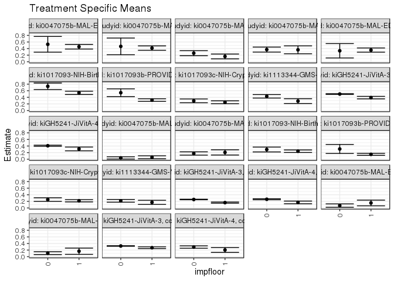

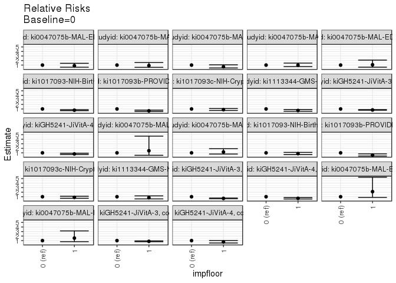

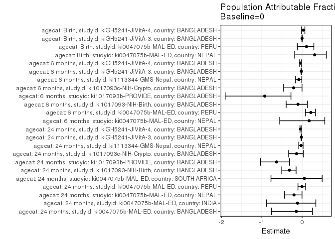

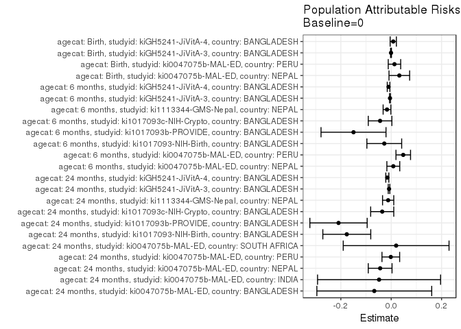

## Results Table

### Parameter: TSM

| agecat | studyid | country | intervention_level | baseline_level | estimate | ci_lower | ci_upper |
| --- | --- | --- | --- | --- | --- | --- | --- |
| Birth | ki0047075b-MAL-ED | NEPAL | 0 | NA | 0.0714286 | 0.0202831 | 0.1225740 |
| Birth | ki0047075b-MAL-ED | NEPAL | 1 | NA | 0.1515152 | 0.0647482 | 0.2382821 |
| Birth | ki0047075b-MAL-ED | PERU | 0 | NA | 0.1067175 | 0.0635630 | 0.1498721 |
| Birth | ki0047075b-MAL-ED | PERU | 1 | NA | 0.1657687 | 0.0701700 | 0.2613674 |
| Birth | kiGH5241-JiVitA-3 | BANGLADESH | 0 | NA | 0.3240892 | 0.3163017 | 0.3318767 |
| Birth | kiGH5241-JiVitA-3 | BANGLADESH | 1 | NA | 0.2716265 | 0.2448951 | 0.2983580 |
| Birth | kiGH5241-JiVitA-4 | BANGLADESH | 0 | NA | 0.2923347 | 0.2558290 | 0.3288404 |
| Birth | kiGH5241-JiVitA-4 | BANGLADESH | 1 | NA | 0.2034117 | 0.1300179 | 0.2768055 |
| 6 months | ki0047075b-MAL-ED | NEPAL | 0 | NA | 0.0396825 | 0.0055223 | 0.0738427 |
| 6 months | ki0047075b-MAL-ED | NEPAL | 1 | NA | 0.0582524 | 0.0129205 | 0.1035843 |
| 6 months | ki0047075b-MAL-ED | PERU | 0 | NA | 0.1743596 | 0.1246916 | 0.2240276 |
| 6 months | ki0047075b-MAL-ED | PERU | 1 | NA | 0.2067650 | 0.1275357 | 0.2859943 |
| 6 months | ki1017093-NIH-Birth | BANGLADESH | 0 | NA | 0.2947723 | 0.2209504 | 0.3685941 |
| 6 months | ki1017093-NIH-Birth | BANGLADESH | 1 | NA | 0.2433005 | 0.2053747 | 0.2812263 |
| 6 months | ki1017093b-PROVIDE | BANGLADESH | 0 | NA | 0.3109072 | 0.1742749 | 0.4475395 |
| 6 months | ki1017093b-PROVIDE | BANGLADESH | 1 | NA | 0.1479953 | 0.1181350 | 0.1778556 |
| 6 months | ki1017093c-NIH-Crypto | BANGLADESH | 0 | NA | 0.2539405 | 0.1997802 | 0.3081008 |
| 6 months | ki1017093c-NIH-Crypto | BANGLADESH | 1 | NA | 0.2177403 | 0.1836409 | 0.2518396 |
| 6 months | ki1113344-GMS-Nepal | NEPAL | 0 | NA | 0.2161912 | 0.1746280 | 0.2577545 |
| 6 months | ki1113344-GMS-Nepal | NEPAL | 1 | NA | 0.1700787 | 0.1077267 | 0.2324308 |
| 6 months | kiGH5241-JiVitA-3 | BANGLADESH | 0 | NA | 0.2562319 | 0.2479679 | 0.2644960 |
| 6 months | kiGH5241-JiVitA-3 | BANGLADESH | 1 | NA | 0.1614455 | 0.1430591 | 0.1798319 |
| 6 months | kiGH5241-JiVitA-4 | BANGLADESH | 0 | NA | 0.2629800 | 0.2476327 | 0.2783273 |
| 6 months | kiGH5241-JiVitA-4 | BANGLADESH | 1 | NA | 0.1677120 | 0.1268581 | 0.2085659 |
| 24 months | ki0047075b-MAL-ED | BANGLADESH | 0 | NA | 0.5294118 | 0.2915812 | 0.7672423 |
| 24 months | ki0047075b-MAL-ED | BANGLADESH | 1 | NA | 0.4564103 | 0.3863340 | 0.5264865 |
| 24 months | ki0047075b-MAL-ED | INDIA | 0 | NA | 0.4666667 | 0.2136414 | 0.7196920 |
| 24 months | ki0047075b-MAL-ED | INDIA | 1 | NA | 0.4150943 | 0.3486198 | 0.4815689 |
| 24 months | ki0047075b-MAL-ED | NEPAL | 0 | NA | 0.2610689 | 0.1843273 | 0.3378106 |
| 24 months | ki0047075b-MAL-ED | NEPAL | 1 | NA | 0.1614333 | 0.0886417 | 0.2342249 |
| 24 months | ki0047075b-MAL-ED | PERU | 0 | NA | 0.3697044 | 0.2936430 | 0.4457657 |
| 24 months | ki0047075b-MAL-ED | PERU | 1 | NA | 0.3623377 | 0.2426648 | 0.4820105 |
| 24 months | ki0047075b-MAL-ED | SOUTH AFRICA | 0 | NA | 0.3333333 | 0.1151006 | 0.5515661 |
| 24 months | ki0047075b-MAL-ED | SOUTH AFRICA | 1 | NA | 0.3545455 | 0.2911994 | 0.4178915 |
| 24 months | ki1017093-NIH-Birth | BANGLADESH | 0 | NA | 0.7337491 | 0.6351222 | 0.8323760 |
| 24 months | ki1017093-NIH-Birth | BANGLADESH | 1 | NA | 0.5357814 | 0.4856481 | 0.5859147 |
| 24 months | ki1017093b-PROVIDE | BANGLADESH | 0 | NA | 0.5384944 | 0.4203847 | 0.6566040 |
| 24 months | ki1017093b-PROVIDE | BANGLADESH | 1 | NA | 0.3164776 | 0.2769838 | 0.3559713 |
| 24 months | ki1017093c-NIH-Crypto | BANGLADESH | 0 | NA | 0.2924709 | 0.2352007 | 0.3497411 |
| 24 months | ki1017093c-NIH-Crypto | BANGLADESH | 1 | NA | 0.2490881 | 0.2056750 | 0.2925012 |
| 24 months | ki1113344-GMS-Nepal | NEPAL | 0 | NA | 0.4302528 | 0.3769153 | 0.4835902 |
| 24 months | ki1113344-GMS-Nepal | NEPAL | 1 | NA | 0.2846110 | 0.2114543 | 0.3577676 |
| 24 months | kiGH5241-JiVitA-3 | BANGLADESH | 0 | NA | 0.4992285 | 0.4860276 | 0.5124295 |
| 24 months | kiGH5241-JiVitA-3 | BANGLADESH | 1 | NA | 0.3911641 | 0.3530976 | 0.4292306 |
| 24 months | kiGH5241-JiVitA-4 | BANGLADESH | 0 | NA | 0.4085996 | 0.3908552 | 0.4263440 |
| 24 months | kiGH5241-JiVitA-4 | BANGLADESH | 1 | NA | 0.3118929 | 0.2545068 | 0.3692789 |

### Parameter: E(Y)

| agecat | studyid | country | intervention_level | baseline_level | estimate | ci_lower | ci_upper |
| --- | --- | --- | --- | --- | --- | --- | --- |
| Birth | ki0047075b-MAL-ED | NEPAL | NA | NA | 0.1036585 | 0.0568642 | 0.1504529 |
| Birth | ki0047075b-MAL-ED | PERU | NA | NA | 0.1196911 | 0.0800828 | 0.1592995 |
| Birth | kiGH5241-JiVitA-3 | BANGLADESH | NA | NA | 0.3233655 | 0.3156750 | 0.3310561 |
| Birth | kiGH5241-JiVitA-4 | BANGLADESH | NA | NA | 0.3004866 | 0.2649179 | 0.3360553 |
| 6 months | ki0047075b-MAL-ED | NEPAL | NA | NA | 0.0480349 | 0.0202781 | 0.0757918 |
| 6 months | ki0047075b-MAL-ED | PERU | NA | NA | 0.2222222 | 0.1725409 | 0.2719036 |
| 6 months | ki1017093-NIH-Birth | BANGLADESH | NA | NA | 0.2672897 | 0.2297549 | 0.3048246 |
| 6 months | ki1017093b-PROVIDE | BANGLADESH | NA | NA | 0.1612350 | 0.1313580 | 0.1911120 |
| 6 months | ki1017093c-NIH-Crypto | BANGLADESH | NA | NA | 0.2097902 | 0.1799252 | 0.2396552 |
| 6 months | ki1113344-GMS-Nepal | NEPAL | NA | NA | 0.1995465 | 0.1622033 | 0.2368897 |
| 6 months | kiGH5241-JiVitA-3 | BANGLADESH | NA | NA | 0.2514552 | 0.2433078 | 0.2596026 |
| 6 months | kiGH5241-JiVitA-4 | BANGLADESH | NA | NA | 0.2525424 | 0.2384154 | 0.2666693 |
| 24 months | ki0047075b-MAL-ED | BANGLADESH | NA | NA | 0.4622642 | 0.3949918 | 0.5295365 |
| 24 months | ki0047075b-MAL-ED | INDIA | NA | NA | 0.4185022 | 0.3541865 | 0.4828179 |
| 24 months | ki0047075b-MAL-ED | NEPAL | NA | NA | 0.2171946 | 0.1627082 | 0.2716810 |
| 24 months | ki0047075b-MAL-ED | PERU | NA | NA | 0.3681592 | 0.3013164 | 0.4350020 |
| 24 months | ki0047075b-MAL-ED | SOUTH AFRICA | NA | NA | 0.3529412 | 0.2921001 | 0.4137823 |
| 24 months | ki1017093-NIH-Birth | BANGLADESH | NA | NA | 0.5573770 | 0.5102104 | 0.6045437 |
| 24 months | ki1017093b-PROVIDE | BANGLADESH | NA | NA | 0.3292894 | 0.2909105 | 0.3676684 |
| 24 months | ki1017093c-NIH-Crypto | BANGLADESH | NA | NA | 0.2568093 | 0.2190047 | 0.2946140 |
| 24 months | ki1113344-GMS-Nepal | NEPAL | NA | NA | 0.4181818 | 0.3688464 | 0.4675172 |
| 24 months | kiGH5241-JiVitA-3 | BANGLADESH | NA | NA | 0.4906286 | 0.4775270 | 0.5037303 |
| 24 months | kiGH5241-JiVitA-4 | BANGLADESH | NA | NA | 0.3931384 | 0.3759466 | 0.4103302 |

### Parameter: RR

| agecat | studyid | country | intervention_level | baseline_level | estimate | ci_lower | ci_upper |
| --- | --- | --- | --- | --- | --- | --- | --- |
| Birth | ki0047075b-MAL-ED | NEPAL | 0 | 0 | 1.0000000 | 1.0000000 | 1.0000000 |
| Birth | ki0047075b-MAL-ED | NEPAL | 1 | 0 | 2.1212121 | 0.8479942 | 5.3060989 |
| Birth | ki0047075b-MAL-ED | PERU | 0 | 0 | 1.0000000 | 1.0000000 | 1.0000000 |
| Birth | ki0047075b-MAL-ED | PERU | 1 | 0 | 1.5533406 | 0.7686075 | 3.1392705 |
| Birth | kiGH5241-JiVitA-3 | BANGLADESH | 0 | 0 | 1.0000000 | 1.0000000 | 1.0000000 |
| Birth | kiGH5241-JiVitA-3 | BANGLADESH | 1 | 0 | 0.8381228 | 0.7581619 | 0.9265170 |
| Birth | kiGH5241-JiVitA-4 | BANGLADESH | 0 | 0 | 1.0000000 | 1.0000000 | 1.0000000 |
| Birth | kiGH5241-JiVitA-4 | BANGLADESH | 1 | 0 | 0.6958179 | 0.4753702 | 1.0184957 |
| 6 months | ki0047075b-MAL-ED | NEPAL | 0 | 0 | 1.0000000 | 1.0000000 | 1.0000000 |
| 6 months | ki0047075b-MAL-ED | NEPAL | 1 | 0 | 1.4679612 | 0.4599809 | 4.6847810 |
| 6 months | ki0047075b-MAL-ED | PERU | 0 | 0 | 1.0000000 | 1.0000000 | 1.0000000 |
| 6 months | ki0047075b-MAL-ED | PERU | 1 | 0 | 1.1858539 | 0.7358409 | 1.9110781 |
| 6 months | ki1017093-NIH-Birth | BANGLADESH | 0 | 0 | 1.0000000 | 1.0000000 | 1.0000000 |
| 6 months | ki1017093-NIH-Birth | BANGLADESH | 1 | 0 | 0.8253845 | 0.6169469 | 1.1042435 |
| 6 months | ki1017093b-PROVIDE | BANGLADESH | 0 | 0 | 1.0000000 | 1.0000000 | 1.0000000 |
| 6 months | ki1017093b-PROVIDE | BANGLADESH | 1 | 0 | 0.4760111 | 0.2940217 | 0.7706457 |
| 6 months | ki1017093c-NIH-Crypto | BANGLADESH | 0 | 0 | 1.0000000 | 1.0000000 | 1.0000000 |
| 6 months | ki1017093c-NIH-Crypto | BANGLADESH | 1 | 0 | 0.8574461 | 0.6595037 | 1.1147985 |
| 6 months | ki1113344-GMS-Nepal | NEPAL | 0 | 0 | 1.0000000 | 1.0000000 | 1.0000000 |
| 6 months | ki1113344-GMS-Nepal | NEPAL | 1 | 0 | 0.7867050 | 0.5201961 | 1.1897530 |
| 6 months | kiGH5241-JiVitA-3 | BANGLADESH | 0 | 0 | 1.0000000 | 1.0000000 | 1.0000000 |
| 6 months | kiGH5241-JiVitA-3 | BANGLADESH | 1 | 0 | 0.6300757 | 0.5608949 | 0.7077893 |
| 6 months | kiGH5241-JiVitA-4 | BANGLADESH | 0 | 0 | 1.0000000 | 1.0000000 | 1.0000000 |
| 6 months | kiGH5241-JiVitA-4 | BANGLADESH | 1 | 0 | 0.6377367 | 0.4962203 | 0.8196119 |
| 24 months | ki0047075b-MAL-ED | BANGLADESH | 0 | 0 | 1.0000000 | 1.0000000 | 1.0000000 |
| 24 months | ki0047075b-MAL-ED | BANGLADESH | 1 | 0 | 0.8621083 | 0.5362669 | 1.3859341 |
| 24 months | ki0047075b-MAL-ED | INDIA | 0 | 0 | 1.0000000 | 1.0000000 | 1.0000000 |
| 24 months | ki0047075b-MAL-ED | INDIA | 1 | 0 | 0.8894879 | 0.5053713 | 1.5655592 |
| 24 months | ki0047075b-MAL-ED | NEPAL | 0 | 0 | 1.0000000 | 1.0000000 | 1.0000000 |
| 24 months | ki0047075b-MAL-ED | NEPAL | 1 | 0 | 0.6183552 | 0.3611453 | 1.0587516 |
| 24 months | ki0047075b-MAL-ED | PERU | 0 | 0 | 1.0000000 | 1.0000000 | 1.0000000 |
| 24 months | ki0047075b-MAL-ED | PERU | 1 | 0 | 0.9800740 | 0.6698022 | 1.4340728 |
| 24 months | ki0047075b-MAL-ED | SOUTH AFRICA | 0 | 0 | 1.0000000 | 1.0000000 | 1.0000000 |
| 24 months | ki0047075b-MAL-ED | SOUTH AFRICA | 1 | 0 | 1.0636364 | 0.5395896 | 2.0966346 |
| 24 months | ki1017093-NIH-Birth | BANGLADESH | 0 | 0 | 1.0000000 | 1.0000000 | 1.0000000 |
| 24 months | ki1017093-NIH-Birth | BANGLADESH | 1 | 0 | 0.7301970 | 0.6225670 | 0.8564341 |
| 24 months | ki1017093b-PROVIDE | BANGLADESH | 0 | 0 | 1.0000000 | 1.0000000 | 1.0000000 |
| 24 months | ki1017093b-PROVIDE | BANGLADESH | 1 | 0 | 0.5877082 | 0.4566529 | 0.7563753 |
| 24 months | ki1017093c-NIH-Crypto | BANGLADESH | 0 | 0 | 1.0000000 | 1.0000000 | 1.0000000 |
| 24 months | ki1017093c-NIH-Crypto | BANGLADESH | 1 | 0 | 0.8516680 | 0.6599552 | 1.0990722 |
| 24 months | ki1113344-GMS-Nepal | NEPAL | 0 | 0 | 1.0000000 | 1.0000000 | 1.0000000 |
| 24 months | ki1113344-GMS-Nepal | NEPAL | 1 | 0 | 0.6614970 | 0.4973093 | 0.8798917 |
| 24 months | kiGH5241-JiVitA-3 | BANGLADESH | 0 | 0 | 1.0000000 | 1.0000000 | 1.0000000 |
| 24 months | kiGH5241-JiVitA-3 | BANGLADESH | 1 | 0 | 0.7835370 | 0.7092061 | 0.8656585 |
| 24 months | kiGH5241-JiVitA-4 | BANGLADESH | 0 | 0 | 1.0000000 | 1.0000000 | 1.0000000 |
| 24 months | kiGH5241-JiVitA-4 | BANGLADESH | 1 | 0 | 0.7633216 | 0.6333475 | 0.9199686 |

### Parameter: PAR

| agecat | studyid | country | intervention_level | baseline_level | estimate | ci_lower | ci_upper |
| --- | --- | --- | --- | --- | --- | --- | --- |
| Birth | ki0047075b-MAL-ED | NEPAL | 0 | NA | 0.0322300 | -0.0087493 | 0.0732093 |
| Birth | ki0047075b-MAL-ED | PERU | 0 | NA | 0.0129736 | -0.0117228 | 0.0376700 |
| Birth | kiGH5241-JiVitA-3 | BANGLADESH | 0 | NA | -0.0007236 | -0.0024768 | 0.0010295 |
| Birth | kiGH5241-JiVitA-4 | BANGLADESH | 0 | NA | 0.0081519 | -0.0042212 | 0.0205251 |
| 6 months | ki0047075b-MAL-ED | NEPAL | 0 | NA | 0.0083524 | -0.0172062 | 0.0339110 |
| 6 months | ki0047075b-MAL-ED | PERU | 0 | NA | 0.0478626 | 0.0189178 | 0.0768075 |
| 6 months | ki1017093-NIH-Birth | BANGLADESH | 0 | NA | -0.0274826 | -0.0965660 | 0.0416009 |
| 6 months | ki1017093b-PROVIDE | BANGLADESH | 0 | NA | -0.1496722 | -0.2786955 | -0.0206488 |
| 6 months | ki1017093c-NIH-Crypto | BANGLADESH | 0 | NA | -0.0441503 | -0.0910338 | 0.0027332 |
| 6 months | ki1113344-GMS-Nepal | NEPAL | 0 | NA | -0.0166447 | -0.0320313 | -0.0012582 |
| 6 months | kiGH5241-JiVitA-3 | BANGLADESH | 0 | NA | -0.0047767 | -0.0065642 | -0.0029893 |
| 6 months | kiGH5241-JiVitA-4 | BANGLADESH | 0 | NA | -0.0104377 | -0.0156304 | -0.0052449 |
| 24 months | ki0047075b-MAL-ED | BANGLADESH | 0 | NA | -0.0671476 | -0.2952210 | 0.1609257 |
| 24 months | ki0047075b-MAL-ED | INDIA | 0 | NA | -0.0481645 | -0.2924947 | 0.1961658 |
| 24 months | ki0047075b-MAL-ED | NEPAL | 0 | NA | -0.0438743 | -0.0910816 | 0.0033329 |
| 24 months | ki0047075b-MAL-ED | PERU | 0 | NA | -0.0015452 | -0.0366446 | 0.0335542 |
| 24 months | ki0047075b-MAL-ED | SOUTH AFRICA | 0 | NA | 0.0196078 | -0.1904476 | 0.2296633 |
| 24 months | ki1017093-NIH-Birth | BANGLADESH | 0 | NA | -0.1763721 | -0.2715313 | -0.0812128 |
| 24 months | ki1017093b-PROVIDE | BANGLADESH | 0 | NA | -0.2092049 | -0.3230458 | -0.0953641 |
| 24 months | ki1017093c-NIH-Crypto | BANGLADESH | 0 | NA | -0.0356615 | -0.0815228 | 0.0101997 |
| 24 months | ki1113344-GMS-Nepal | NEPAL | 0 | NA | -0.0120710 | -0.0343183 | 0.0101763 |
| 24 months | kiGH5241-JiVitA-3 | BANGLADESH | 0 | NA | -0.0085999 | -0.0117644 | -0.0054354 |
| 24 months | kiGH5241-JiVitA-4 | BANGLADESH | 0 | NA | -0.0154612 | -0.0214948 | -0.0094276 |

### Parameter: PAF

| agecat | studyid | country | intervention_level | baseline_level | estimate | ci_lower | ci_upper |
| --- | --- | --- | --- | --- | --- | --- | --- |
| Birth | ki0047075b-MAL-ED | NEPAL | 0 | NA | 0.3109244 | -0.1853733 | 0.5994298 |
| Birth | ki0047075b-MAL-ED | PERU | 0 | NA | 0.1083921 | -0.1203708 | 0.2904451 |
| Birth | kiGH5241-JiVitA-3 | BANGLADESH | 0 | NA | -0.0022378 | -0.0076774 | 0.0031724 |
| Birth | kiGH5241-JiVitA-4 | BANGLADESH | 0 | NA | 0.0271291 | -0.0147363 | 0.0672672 |
| 6 months | ki0047075b-MAL-ED | NEPAL | 0 | NA | 0.1738817 | -0.5565077 | 0.5615367 |
| 6 months | ki0047075b-MAL-ED | PERU | 0 | NA | 0.2153818 | 0.0798776 | 0.3309307 |
| 6 months | ki1017093-NIH-Birth | BANGLADESH | 0 | NA | -0.1028194 | -0.3971502 | 0.1295062 |
| 6 months | ki1017093b-PROVIDE | BANGLADESH | 0 | NA | -0.9282859 | -1.9099459 | -0.2777855 |
| 6 months | ki1017093c-NIH-Crypto | BANGLADESH | 0 | NA | -0.2104497 | -0.4602892 | -0.0033550 |
| 6 months | ki1113344-GMS-Nepal | NEPAL | 0 | NA | -0.0834129 | -0.1636231 | -0.0087317 |
| 6 months | kiGH5241-JiVitA-3 | BANGLADESH | 0 | NA | -0.0189964 | -0.0261834 | -0.0118597 |
| 6 months | kiGH5241-JiVitA-4 | BANGLADESH | 0 | NA | -0.0413303 | -0.0620844 | -0.0209818 |
| 24 months | ki0047075b-MAL-ED | BANGLADESH | 0 | NA | -0.1452581 | -0.7626498 | 0.2558839 |
| 24 months | ki0047075b-MAL-ED | INDIA | 0 | NA | -0.1150877 | -0.8825801 | 0.3395125 |
| 24 months | ki0047075b-MAL-ED | NEPAL | 0 | NA | -0.2020048 | -0.4391546 | -0.0039335 |
| 24 months | ki0047075b-MAL-ED | PERU | 0 | NA | -0.0041971 | -0.1041951 | 0.0867450 |
| 24 months | ki0047075b-MAL-ED | SOUTH AFRICA | 0 | NA | 0.0555556 | -0.7735984 | 0.4970816 |
| 24 months | ki1017093-NIH-Birth | BANGLADESH | 0 | NA | -0.3164322 | -0.5062616 | -0.1505264 |
| 24 months | ki1017093b-PROVIDE | BANGLADESH | 0 | NA | -0.6353224 | -1.0349541 | -0.3141718 |
| 24 months | ki1017093c-NIH-Crypto | BANGLADESH | 0 | NA | -0.1388639 | -0.3352986 | 0.0286734 |
| 24 months | ki1113344-GMS-Nepal | NEPAL | 0 | NA | -0.0288654 | -0.0837164 | 0.0232095 |
| 24 months | kiGH5241-JiVitA-3 | BANGLADESH | 0 | NA | -0.0175283 | -0.0240577 | -0.0110407 |
| 24 months | kiGH5241-JiVitA-4 | BANGLADESH | 0 | NA | -0.0393276 | -0.0550285 | -0.0238603 |